# EDS 213 Group Project

Halina Do-Linh, Marie Rivers, Allie Cole

2021-10-27

### Pulling Down Data with Metajam

- Each data set is loaded into the `data` folder and then a corresponding folder specifically for that data set

#### Otter Data

Otter data was obtained from DataONE Data Catalog. See citation:

> Santa Barbara Coastal LTER, Daniel C Reed, Shannon Harrer, Clint J Nelson, and Robert J Miller. 2021. SBC LTER: Reef: Sightings of sea otters (Enhydra lutris) near Santa Barbara and Channel Islands, ongoing since 2007.

```r
data_lter_url <- "https://cn.dataone.org/cn/v2/resolve/https%3A%2F%2Fpasta.lternet.edu%2Fpackage%2Fdata%2Feml%2Fknb-lter-sbc%2F61%2F8%2F85e13b27599bf1ed68c7930674e1e7bd"

metajam::download_d1_data(data_lter_url, "data", "counts_sb")
```

```r
otter_folder <- file.path("data", "counts_sb")
```

#### Urchin Data

Urchin data data was obtained from DataONE Data Catalog. See citation:

> Santa Barbara Coastal LTER, Steven C Schroeter, John Douglas Dixon, Thomas Ebert, and John Richards. 2021. SBC LTER: Settlement of urchins and other invertebrates, ongoing since 1990. LTER Network Member

```r
data_urchins_url <- "https://cn.dataone.org/cn/v2/resolve/https%3A%2F%2Fpasta.lternet.edu%2Fpackage%2Fdata%2Feml%2Fknb-lter-sbc%2F52%2F10%2F6f1d97294f041ee3d39cda102e0223af"

metajam::download_d1_data(data_urchins_url, "data", "urchins")
```

```r
urchin_folder <- system.file("data", "counts_sb")
```

### Visualizing and Cleaning the Data

We then created a visualization of each species to display the total counts.

#### Otter Data

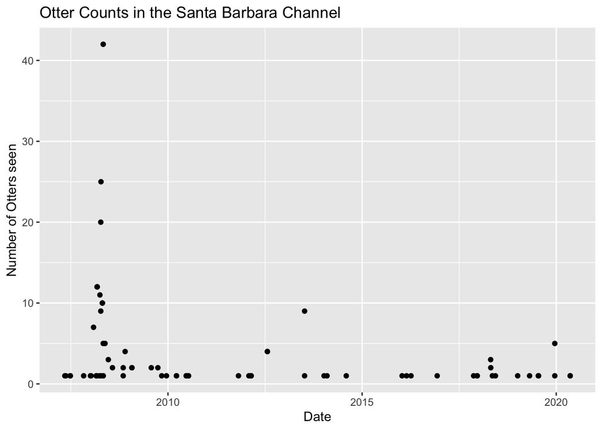

```r
otter_LTER <- read_d1_files(otter_folder, fnc = "read_csv")
otter_LTER_data <- otter_LTER$data


otter_LTER_data <- otter_LTER_data %>%
  filter(YEAR <= 2020) %>%
  filter(COUNT > 0) %>%
  mutate(SITE = SBC_SITE) %>%
  mutate(SPECIES = "sea otter") %>%
  select(DATE, SITE, SPECIES, COUNT)

ggplot(data = otter_LTER_data, aes(x = DATE, y = COUNT)) +
  geom_point() +
  labs(title = "Otter Counts in the Santa Barbara Channel",
       x = "Date",
       y = "Number of Otters seen")
```

#### Urchin Data

```r
urchins <- read_csv("https://cn.dataone.org/cn/v2/resolve/https%3A%2F%2Fpasta.lternet.edu%2Fpackage%2Fdata%2Feml%2Fknb-lter-sbc%2F52%2F10%2F6f1d97294f041ee3d39cda102e0223af", na = "-99999") %>%
  mutate(DATE = lubridate::mdy(DATE_RETRIEVED)) %>%
  filter(DATE >= "2007-01-01") %>%
  filter(TOTAL_URCHINS > 0) %>%
  mutate(SPECIES = "urchin") %>%
  mutate(COUNT = TOTAL_URCHINS) %>%
  select(DATE, SITE, SPECIES, COUNT)

urchins
```

```
## # A tibble: 2,009 × 4
##    DATE       SITE    SPECIES COUNT
##    <date>     <chr>   <chr>   <dbl>
##  1 2007-06-20 ANACAPA urchin     23
##  2 2007-06-20 ANACAPA urchin     28
##  3 2007-06-20 ANACAPA urchin      8
##  4 2007-06-20 ANACAPA urchin     14
##  5 2007-07-05 ANACAPA urchin      3
##  6 2007-07-05 ANACAPA urchin      1
##  7 2007-07-05 ANACAPA urchin      6
##  8 2008-01-15 ANACAPA urchin      8
##  9 2008-01-15 ANACAPA urchin     19
## 10 2008-01-15 ANACAPA urchin     18
## # … with 1,999 more rows
```

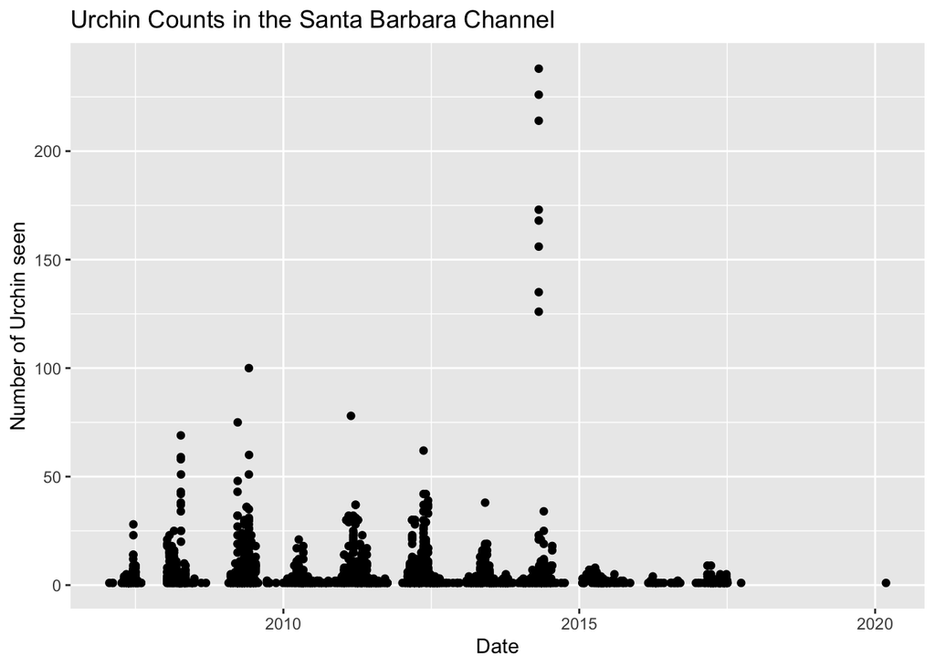

```r
ggplot(data = urchins, aes(x = DATE, y = COUNT)) +
  geom_point() +
   labs(title = "Urchin Counts in the Santa Barbara Channel",
       x = "Date",
       y = "Number of Urchin seen")
```

### Combining Data Sets into one Data Frame

We then combined the 2 datasets using `rbind` and visualized counts of both species on one plot.

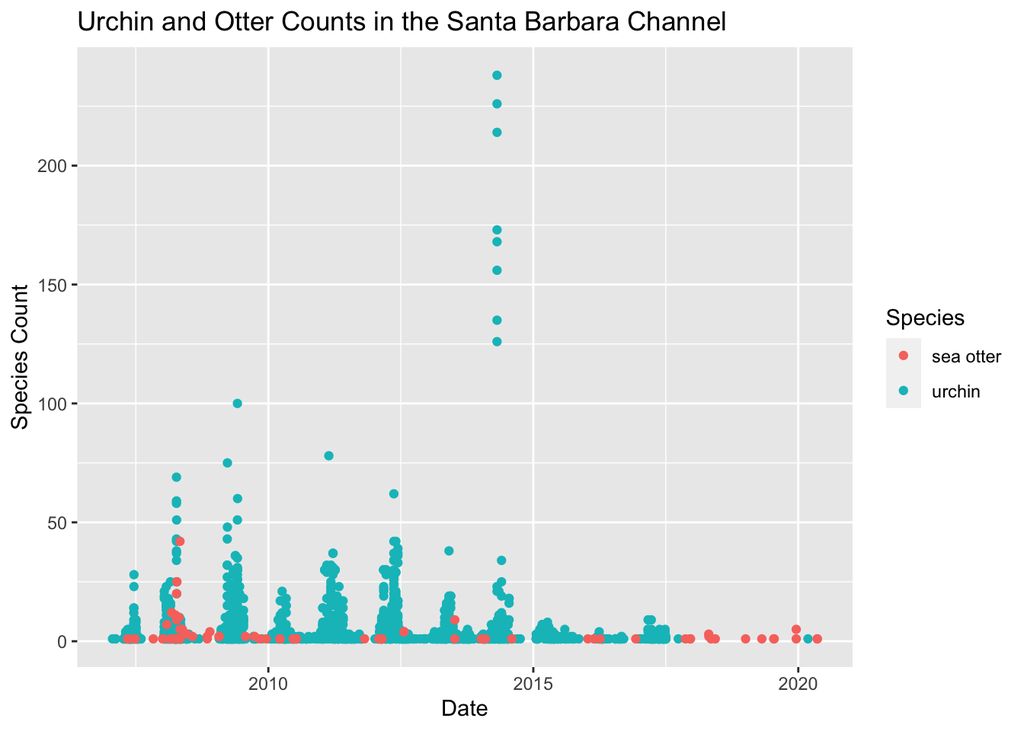

```r
combined_data <- rbind(urchins, otter_LTER_data)

ggplot(data = combined_data, aes(x = DATE, y = COUNT, color = SPECIES)) +
  geom_point() +
   labs(title = "Urchin and Otter Counts in the Santa Barbara Channel",
       x = "Date",
       y = "Species Count",
       color = "Species")
```

### Saving the df as a .csv file

To make our new combined dataset reproducible and accessible, we created a `csv` file to be added to our GitHub and our KNB repository.

```r
write.csv(combined_data,"clean_data\\sb_otter_urchin_counts.csv", row.names = TRUE)
```

### Final Thoughts

- We did not have time to do a more in depth analysis, as the time was short and we spent a long time looking for data. If we had been able to access the USGS data set, we think that this could have been a much more comprehensive review of the two species populations.
- Further, if we had been able to use the USGS data we would have expanded our sites in include more of the West Coast, not just the Santa Barbara Channel. We found a few data sets that ranged from Canada down to Mexico, however with the short time span we did not request access from USGS.